# From Session 4.

#### Roll.No:- 29

```r
# create new variable y and assign value from 1 to 10 of length 5 to it. that means it contain 5 observations.
y <- seq(1,10,length.out = 5)
(y <- seq(1,10,length.out = 5)) #Enclosing the function by parenthesis directly print out our result.
```

[output not shown]

`Length.out` is the argument that decides the total length of the sequence. `Seq()`: The seq function in R can generate the general or regular sequences from the given inputs.

`seq(from, to, by, length.out, along.with)`

- From = beginning number of the sequence.
- To = Terminating the number of the sequence.
- by = It is the increment of the given sequence. It is calculated as ((to-from) /(length.out-1)).
- length.out = Decides the total length of the sequence.
- along.with = Outputs a sequence of the same length as the input vector.

```r
# Assign variable name a with column vector from 1 to 10
a <- 1:10
# check class of a
class(a)
```

'integer'

Class of a is integer type means it is whole number.

```r
#Assign b with single vector 5
b <- 5
# check out the class of b.
class(b)
```

'numeric'

Class of b is numeric it means it can be whole number as well as whole number.

```r
#Here we assign the value of c with column vector(2,3,4,5,6,7,8,9,10,11 )
c <- c(2,3,4,5,6,7,8,9,10,11)
#Test class of c.
class(c)
```

'numeric'

```r
# Multiply a and b already define above and assign it's value as ac.

ac <- a*c
ac
# test of class c.
class(ac)
```

1. 2

2. 6

3. 12

4. 20

5. 30

6. 42

7. 56

8. 72

9. 90

10. 110

'numeric'

```r
#Here multiply ac with (which is obtaibed in previous shell) b and assign value abc to it.
acb <- ac*b
acb
```

1. 10

2. 30

3. 60

4. 100

5. 150

6. 210

7. 280

8. 360

9. 450

10. 550

```r
# Here we combine a and c in the same data frame by using cbind function.
x <- cbind(a,c)
x
```

| a | c |
| --- | --- |
| 1 | 2 |
| 2 | 3 |
| 3 | 4 |
| 4 | 5 |
| 5 | 6 |
| 6 | 7 |
| 7 | 8 |
| 8 | 9 |
| 9 | 10 |
| 10 | 11 |

cbind is a merge function that can be used to combine two data frames with the same number of multiple rows into a single data frame.

```r
# Here we assign new variable d by taking mean value of rows by using builtin funtion rowMean().
d <- rowMeans(x)
d
```

1. 1.5

2. 2.5

3. 3.5

4. 4.5

5. 5.5

6. 6.5

7. 7.5

8. 8.5

9. 9.5

10. 10.5

```r
#Here we combine x and d by using cbind function. To merge two data frame into single data frame.
abcd <- cbind(x,d)
abcd
```

| a | c | d |
| --- | --- | --- |
| 1 | 2 | 1.5 |
| 2 | 3 | 2.5 |
| 3 | 4 | 3.5 |
| 4 | 5 | 4.5 |
| 5 | 6 | 5.5 |
| 6 | 7 | 6.5 |
| 7 | 8 | 7.5 |
| 8 | 9 | 8.5 |
| 9 | 10 | 9.5 |
| 10 | 11 | 10.5 |

```r
summary(abcd)
```

```
       a               c               d
 Min.   : 1.00   Min.   : 2.00   Min.   : 1.50
 1st Qu.: 3.25   1st Qu.: 4.25   1st Qu.: 3.75
 Median : 5.50   Median : 6.50   Median : 6.00
 Mean   : 5.50   Mean   : 6.50   Mean   : 6.00
 3rd Qu.: 7.75   3rd Qu.: 8.75   3rd Qu.: 8.25
 Max.   :10.00   Max.   :11.00   Max.   :10.50
```

Here we calculate the summary of dataframe abcd obtained in previous shell.In summary we can see six value. Mean is 5.50, meadian is 5.50 in this case we see same value for mean and median similarly, value of first and third quartile are 3.25 and 7.75 respectively. Maximum and minimum value is 10 and 1.

```r
a <- 1: 10 # vector of length 10.
b <- 1:5  # vector of length 5
c <- a + b # Matrix addition.
c
```

1. 2

2. 4

3. 6

4. 8

5. 10

6. 7

7. 9

8. 11

9. 13

10. 15

In above code we can see a and b are two different size vectors. So addition of elements of a and b are like at first add first 5 elements of a with five elements of b after that add remaining 5 elements of a with five elements of b. This method is also called vector recycling.

```r
best_practice <- c("let","the","computer","do","work") # we generate column of string.
print_words <- function(sentence){ # create function  assign name print_words having sentence as parameter.
    print(sentence[1])
    print(sentence[2])
    print(sentence[3]) #This is body of the function.
    print(sentence[4])
    print(sentence[5])
    print(sentence[6])
}
print_words(best_practice) #we call the function.
print_words(best_practice[-6])# we already fix the function so it gives NA at last.
best_practice[-6] # It give result because we work on vector not on function.
```

```
[1] "let"
[1] "the"
[1] "computer"
[1] "do"
[1] "work"
[1] NA
[1] "let"
[1] "the"
[1] "computer"
[1] "do"
[1] "work"
[1] NA
```

1. 'let'

2. 'the'

3. 'computer'

4. 'do'

5. 'work'

# Session 5

### Pipe operator:

Pipe operators, available in magrittr, dplyr, and other R packages, process a data-object using a sequence of operations by passing the result of one step as input for the next step using infix-operators. It is denoted by %>%.

```r
#Initialize "x"
x <- c(0.109, 0.359, 0.63, 0.996, 0.515, 0.142, 0.017, 0.829, 0.907)
# In this code at first we calculate log of x and then calculate lagged and iterated difference and then
# compute exponential function and finally round the result.
round(exp(diff(log(x))),1)
```

1. 3.3

2. 1.8

3. 1.6

4. 0.5

5. 0.3

6. 0.1

7. 48.8

8. 1.1

Here we take round(1), it means we gave instruction that ofter dot need to take only one digit.

```r
library(magrittr)
x %>% log() %>%
  diff() %>%
  exp() %>%
  round(1)
```

1. 3.3

2. 1.8

3. 1.6

4. 0.5

5. 0.3

6. 0.1

7. 48.8

8. 1.1

In above we do same operation as in previous shell, but here we used pipe operator. Finally, we get same result.

## rnorm:

The `rnorm ()` is a built-in R function that generates a vector of normally distributed random numbers. It generates the Normal Distributions On Special Spaces. The `rnorm ()` f unction helps to generate random numbers whose distribution is normal.

```r
x <- rnorm(100)
(x %<>% abs %>% sort)
```

1. 0.0108843708668879

2. 0.0251699687207716

3. 0.0564474715551493

4. 0.0567819700740991

5. 0.0799130260467011

6. 0.0936887110809161

7. 0.104924660094709

8. 0.129566889068558

9. 0.133408838882049

10. 0.142585714331368

11. 0.190530605640428

12. 0.190863170960976

13. 0.218757494754568

14. 0.221785387779041

15. 0.266452807217006

16. 0.269500412240456

17. 0.274813530709087

18. 0.298925924789206

19. 0.321174835770445

20. 0.328221618149849

21. 0.349575215946469

22. 0.353461175378456

23. 0.373224635984839

24. 0.373297167444994

25. 0.37819063375049

26. 0.404200024526514

27. 0.425274708375034

28. 0.427647414433894

29. 0.457421896782181

30. 0.468265200366682

31. 0.480445616206534

32. 0.486675561809993

33. 0.511397178587076

34. 0.535742342429776

35. 0.543179733820286

36. 0.554547110085492

37. 0.559300463270691

38. 0.559373441848437

39. 0.563440547551052

40. 0.569451483208636

41. 0.570229417621615

42. 0.576066203577466

43. 0.586562892884619

44. 0.589233811756734

45. 0.60030660787724

46. 0.60476430896586

47. 0.62143645459965

48. 0.628838417916222

49. 0.662385873411462

50. 0.665050902340998

51. 0.665419385385718

52. 0.682485142221294

53. 0.707300214139308

54. 0.746492294017828

55. 0.75788615507218

56. 0.773741851450043

57. 0.77498512931967

58. 0.776678269504198

59. 0.791108192866947

60. 0.800201196430074

61. 0.872958198501819

62. 0.8751075178461

63. 0.89460942988906

64. 0.924123384778179

65. 0.936934201273675

66. 0.999237272808635

67. 1.09256568127242

68. 1.10826337942653

69. 1.11938287935416

70. 1.15742109392224

71. 1.16588027784331

72. 1.17001963462762

73. 1.18216246377374

74. 1.1900047543767

75. 1.19702962544137

76. 1.2117742004771

77. 1.21725964116086

78. 1.23740053908301

79. 1.30836957427267

80. 1.33331916101238

81. 1.39262177065881

82. 1.42785658601215

83. 1.48444215348357

84. 1.51355161944903

85. 1.56090609552176

86. 1.56441389595267

87. 1.56488503697039

88. 1.58791521155143

89. 1.61895840216098

90. 1.64785297765465

91. 1.68551716892465

92. 1.71362702425753

93. 1.71906866940337

94. 1.79610961491526

95. 1.83654358191747

96. 1.86567904077208

97. 1.92874832578689

98. 1.97040694855771

99. 2.04983170261838

100. 2.18646485779542

In above code we take 100 vectors of normally distributed random numbers. Also, we take compound assignment operator (%<>%). It is used to perform operation on the same variable. In above at first we take value from x and take absolute value of x and then we sort( kept them in acending order).

1. 3.33124219885312

2. -9.55114508831724

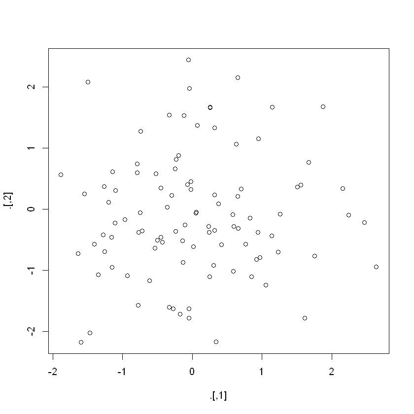

```r
#Other pipe operators 2
rnorm(200) %>%
# to pass parameter we use %T>%. Here we pass normally distributed random numbers as a matrix having 2 columns and all rows.
  matrix(ncol = 2) %T>%
  plot %>%  # here we plot the column value.
  colSums # here we calculate sum of two columns separately.
```

we can decide that above graph is not linear type. Scatter plot shows that value are distributed randomly. There is no any pattern in the graph.

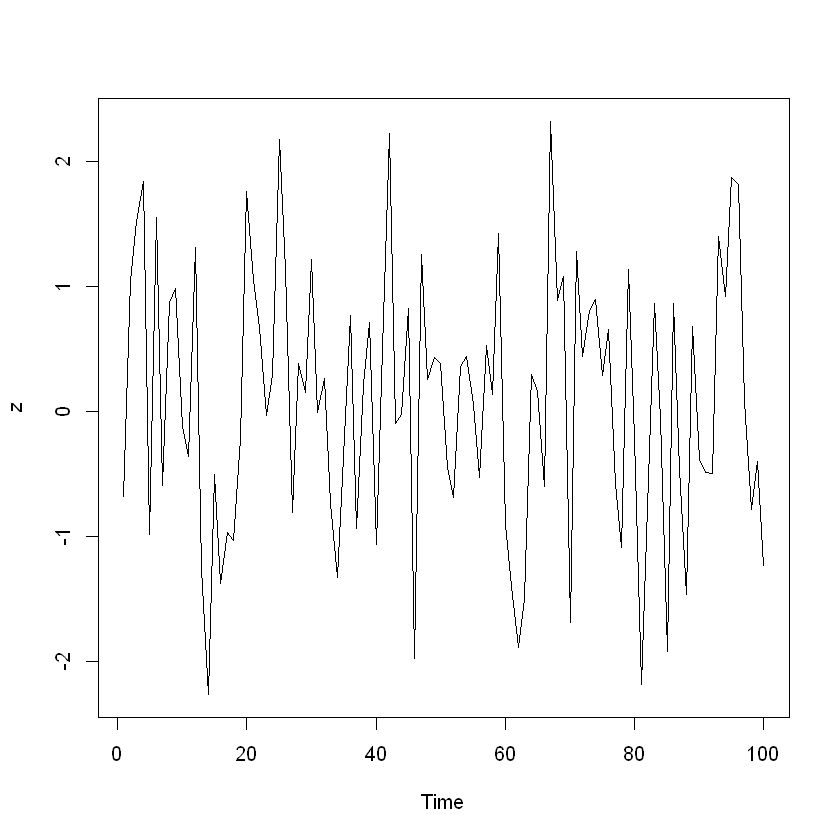

```r
# %$% pipe operator is used when we need to directly plot date in a graph.
data.frame(z = rnorm(100)) %$% # it build data frme of 100 normally distributed random numbers.
  ts.plot(z) # by taking ts it plot date and z
```

According to date value of z is normally distributed.

```r
install.packages("dplyr")
```

```
  There is a binary version available but the source version is later:
      binary source needs_compilation
dplyr  1.0.6  1.0.7              TRUE

  Binaries will be installed
```

```r
#More examples:
#Load the package, install if require!
install.packages("babynames") # we need to install packages if not already in R.
library(babynames) # It load the library babynames
library(dplyr) # It load the library dplyr
data(babynames)#Load the data:
sum(select(filter(babynames,sex=="M",name=="Taylor"),n)) # we select n number of babynames who is male and have name Taylor
# here we use pipe operator to select n number of babynames who is male and have name Taylor
babynames%>%filter(sex=="M",name=="Taylor")%>%
  select(n)%>%
  sum # we sum
```

109852

109852

```r
iris <- read.csv(url("http://archive.ics.uci.edu/ml/machine-learning-databases/iris/iris.data"), header = FALSE)

# Add column names to the Iris data
names(iris) <- c("Sepal.Length", "Sepal.Width", "Petal.Length", "Petal.Width", "Species")
#iris
iris$Sepal.Length.SQRT # it add extra column by sorting sepal.length
  iris$Sepal.Length %>%
  sqrt()
iris
```

[output not shown]

```r
#Compound pipe operator:
# Compute the square root of `iris$Sepal.Length` and assign it to the same variable
Sepal.Length <- iris$Sepal.Length %<>% sqrt
Sepal.Length
```

1. 1.50277009490049

2. 1.48781529838817

3. 1.47239544242295

4. 1.46450027618731

5. 1.49534878122122

6. 1.52439824446384

7. 1.46450027618731

8. 1.49534878122122

9. 1.44831546851517

10. 1.48781529838817

11. 1.52439824446384

12. 1.48016560898457

13. 1.48016560898457

14. 1.44001532468678

15. 1.55187593439632

16. 1.54514312517083

17. 1.52439824446384

18. 1.50277009490049

19. 1.54514312517083

20. 1.50277009490049

21. 1.52439824446384

22. 1.50277009490049

23. 1.46450027618731

24. 1.50277009490049

25. 1.48016560898457

26. 1.49534878122122

27. 1.49534878122122

28. 1.5100830606951

29. 1.5100830606951

30. 1.47239544242295

31. 1.48016560898457

32. 1.52439824446384

33. 1.5100830606951

34. 1.53140715680439

35. 1.48781529838817

36. 1.49534878122122

37. 1.53140715680439

38. 1.48781529838817

39. 1.44831546851517

40. 1.50277009490049

41. 1.49534878122122

42. 1.45647531512197

43. 1.44831546851517

44. 1.49534878122122

45. 1.50277009490049

46. 1.48016560898457

47. 1.50277009490049

48. 1.46450027618731

49. 1.51729129920535

50. 1.49534878122122

51. 1.62657656169779

52. 1.5905414575341

53. 1.62073597705263

54. 1.53140715680439

55. 1.59671843378737

56. 1.54514312517083

57. 1.58429166494122

58. 1.48781529838817

59. 1.60282454302803

60. 1.5100830606951

61. 1.49534878122122

62. 1.55852223606153

63. 1.56508458007329

64. 1.57156540018088

65. 1.53832113462692

66. 1.60886165381271

67. 1.53832113462692

68. 1.55187593439632

69. 1.57796702107419

70. 1.53832113462692

71. 1.55852223606153

72. 1.57156540018088

73. 1.58429166494122

74. 1.57156540018088

75. 1.5905414575341

76. 1.60282454302803

77. 1.61483155842368

78. 1.60886165381271

79. 1.56508458007329

80. 1.54514312517083

81. 1.53140715680439

82. 1.53140715680439

83. 1.55187593439632

84. 1.56508458007329

85. 1.52439824446384

86. 1.56508458007329

87. 1.60886165381271

88. 1.58429166494122

89. 1.53832113462692

90. 1.53140715680439

91. 1.53140715680439

92. 1.57156540018088

93. 1.55187593439632

94. 1.49534878122122

95. 1.53832113462692

96. 1.54514312517083

97. 1.54514312517083

98. 1.57796702107419

99. 1.50277009490049

100. 1.54514312517083

101. 1.58429166494122

102. 1.55187593439632

103. 1.63235489979809

104. 1.58429166494122

105. 1.59671843378737

106. 1.66036434267243

107. 1.48781529838817

108. 1.64373088345424

109. 1.60886165381271

110. 1.63807251762544

111. 1.59671843378737

112. 1.5905414575341

113. 1.61483155842368

114. 1.54514312517083

115. 1.55187593439632

116. 1.5905414575341

117. 1.59671843378737

118. 1.66579932317861

119. 1.66579932317861

120. 1.56508458007329

121. 1.62073597705263

122. 1.53832113462692

123. 1.66579932317861

124. 1.58429166494122

125. 1.60886165381271

126. 1.63807251762544

127. 1.57796702107419

128. 1.57156540018088

129. 1.5905414575341

130. 1.63807251762544

131. 1.64933141052582

132. 1.67651241108172

133. 1.5905414575341

134. 1.58429166494122

135. 1.57156540018088

136. 1.66579932317861

137. 1.58429166494122

138. 1.5905414575341

139. 1.56508458007329

140. 1.62073597705263

141. 1.60886165381271

142. 1.62073597705263

143. 1.55187593439632

144. 1.61483155842368

145. 1.60886165381271

146. 1.60886165381271

147. 1.58429166494122

148. 1.59671843378737

149. 1.57796702107419

150. 1.55852223606153

1. 9.04059086362066

2. -10.7546798003509

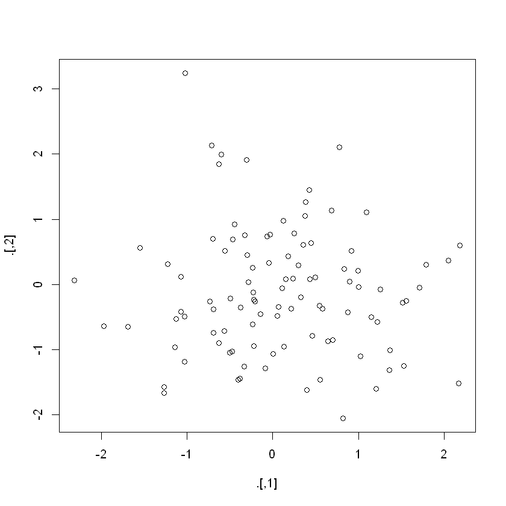

```r
#The tee operator:
set.seed(123)
rnorm(200) %>%
  matrix(ncol = 2) %T>%
  plot %>%
  colSums
```

Here "tee" operator helps to pass the data to the next arguement i.e plot and colSums

```r
#Exposing pipe operator: comes handy when "data" argument is not needed in a function
iris %>%
  subset(Sepal.Length > mean(Sepal.Length)) %$%
# it calculate correlation between Sepal.Length and Sepal.width and there is low degree of positive correlation.
  cor(Sepal.Length, Sepal.Width)
```

0.336696922252551

```r
#The "dplyr" package and its use in data science
install.packages("hflights")
library(hflights)
```

```r
#Without pipe operators:
grouped_flights <- group_by(hflights, Year, Month, DayofMonth)
flights_data <- select(grouped_flights, Year:DayofMonth, ArrDelay, DepDelay)
summarized_flights <- summarise(flights_data,
                                arr = mean(ArrDelay, na.rm = TRUE), 	#Remove missing data!
                                dep = mean(DepDelay, na.rm = TRUE)) 	#Remove missing data!
final_result <- filter(summarized_flights, arr > 30 | dep > 30)
final_result
```

| Year | Month | DayofMonth | arr | dep |
| --- | --- | --- | --- | --- |
| 2011 | 2 | 4 | 44.08088 | 47.17216 |
| 2011 | 3 | 3 | 35.12898 | 38.20064 |
| 2011 | 3 | 14 | 46.63830 | 36.13657 |
| 2011 | 4 | 4 | 38.71651 | 27.94915 |
| 2011 | 4 | 25 | 37.79845 | 22.25574 |
| 2011 | 5 | 12 | 69.52046 | 64.52039 |
| 2011 | 5 | 20 | 37.02857 | 26.55090 |
| 2011 | 6 | 22 | 65.51852 | 62.30979 |
| 2011 | 7 | 29 | 29.55755 | 31.86944 |
| 2011 | 9 | 29 | 39.19649 | 32.49528 |
| 2011 | 10 | 9 | 61.90172 | 59.52586 |
| 2011 | 11 | 15 | 43.68134 | 39.23333 |
| 2011 | 12 | 29 | 26.30096 | 30.78855 |
| 2011 | 12 | 31 | 46.48465 | 54.17137 |

```r
#With pipe operators:
hflights %>% group_by(Year, Month, DayofMonth) %>%
  select(Year:DayofMonth, ArrDelay, DepDelay) %>%
  summarise(arr = mean(ArrDelay, na.rm = TRUE), dep = mean(DepDelay, na.rm = TRUE)) %>%
  filter(arr > 30 | dep > 30)
```

| Year | Month | DayofMonth | arr | dep |
| --- | --- | --- | --- | --- |
| 2011 | 2 | 4 | 44.08088 | 47.17216 |
| 2011 | 3 | 3 | 35.12898 | 38.20064 |
| 2011 | 3 | 14 | 46.63830 | 36.13657 |
| 2011 | 4 | 4 | 38.71651 | 27.94915 |
| 2011 | 4 | 25 | 37.79845 | 22.25574 |
| 2011 | 5 | 12 | 69.52046 | 64.52039 |
| 2011 | 5 | 20 | 37.02857 | 26.55090 |
| 2011 | 6 | 22 | 65.51852 | 62.30979 |
| 2011 | 7 | 29 | 29.55755 | 31.86944 |
| 2011 | 9 | 29 | 39.19649 | 32.49528 |
| 2011 | 10 | 9 | 61.90172 | 59.52586 |
| 2011 | 11 | 15 | 43.68134 | 39.23333 |
| 2011 | 12 | 29 | 26.30096 | 30.78855 |
| 2011 | 12 | 31 | 46.48465 | 54.17137 |

```r
#ARRNGE data with dplyr and pipe operators:
#Ascending order
iris %>%
  select(starts_with("Sepal")) %>%
  fliter(Sepal.Length >=70) %>% # here is error in code in place of fliter we should keep filter.
  arrange(Sepal.Length)		#Sort data in ascending order
```

```
Error in fliter(., Sepal.Length >= 70): could not find function "fliter"
Traceback:

1. iris %>% select(starts_with("Sepal")) %>% fliter(Sepal.Length >=
 .     70) %>% arrange(Sepal.Length)
2. arrange(., Sepal.Length)
```

```r
#ARRNGE data with dplyr and pipe operators:
#Ascending order
iris %>%
  select(starts_with("Sepal")) %>%
  filter(Sepal.Length >=70) %>% # After code edited.
  arrange(Sepal.Length)		#Sort data in ascending order
```

| Sepal.Length | Sepal.Width | Sepal.Length.SQRT |
| --- | --- | --- |

```r
#Descending order:
iris %>%
  select(starts_with("Sepal")) %>%
  fliter(Sepal.Length >=70) %>%
  arrange(desc(Sepal.Length))		#Sort data in descending order
```

```
Error in fliter(., Sepal.Length >= 70): could not find function "fliter"
Traceback:

1. iris %>% select(starts_with("Sepal")) %>% fliter(Sepal.Length >=
 .     70) %>% arrange(desc(Sepal.Length))
2. arrange(., desc(Sepal.Length))
```

Above code gave error message because the spelling mistake of filter.

```r
#Descending order:
iris %>%
  select(starts_with("Sepal")) %>%
  filter(Sepal.Length >=70) %>%
  arrange(desc(Sepal.Length))		#Sort data in descending order
```

| Sepal.Length | Sepal.Width | Sepal.Length.SQRT |
| --- | --- | --- |

```r
#MUTATE with dplyr and pipe operators:
iris %>%
  select(contains("Sepal")) %>%
  mutate(Sepal.Area = Sepal.Lenght * Sepal.Width) # spelling mistake of Sepal.length so error came.

iris %>%
  select(end_with("Length")) %>%
  mutate(Length.Diff = Sepal.Length - Petal.Length)
```

[output not shown]

[output cut: 123 more lines]

[output not shown]

```r
#MUTATE with dplyr and pipe operators:
iris %>%
  select(contains("Sepal")) %>%
  mutate(Sepal.Area = Sepal.Length * Sepal.Width)

iris %>%
  select(end_with("Length")) %>%
  mutate(Length.Diff = Sepal.Length - Petal.Length)
```

| Sepal.Length | Sepal.Width | Sepal.Length.SQRT | Sepal.Area |
| --- | --- | --- | --- |
| 1.502770 | 3.5 | 2.258318 | 5.259695 |
| 1.487815 | 3.0 | 2.213594 | 4.463446 |
| 1.472395 | 3.2 | 2.167948 | 4.711665 |
| 1.464500 | 3.1 | 2.144761 | 4.539951 |
| 1.495349 | 3.6 | 2.236068 | 5.383256 |
| 1.524398 | 3.9 | 2.323790 | 5.945153 |
| 1.464500 | 3.4 | 2.144761 | 4.979301 |
| 1.495349 | 3.4 | 2.236068 | 5.084186 |
| 1.448315 | 2.9 | 2.097618 | 4.200115 |
| 1.487815 | 3.1 | 2.213594 | 4.612227 |
| 1.524398 | 3.7 | 2.323790 | 5.640274 |
| 1.480166 | 3.4 | 2.190890 | 5.032563 |
| 1.480166 | 3.0 | 2.190890 | 4.440497 |
| 1.440015 | 3.0 | 2.073644 | 4.320046 |
| 1.551876 | 4.0 | 2.408319 | 6.207504 |
| 1.545143 | 4.4 | 2.387467 | 6.798630 |
| 1.524398 | 3.9 | 2.323790 | 5.945153 |
| 1.502770 | 3.5 | 2.258318 | 5.259695 |
| 1.545143 | 3.8 | 2.387467 | 5.871544 |
| 1.502770 | 3.8 | 2.258318 | 5.710526 |
| 1.524398 | 3.4 | 2.323790 | 5.182954 |
| 1.502770 | 3.7 | 2.258318 | 5.560249 |
| 1.464500 | 3.6 | 2.144761 | 5.272201 |
| 1.502770 | 3.3 | 2.258318 | 4.959141 |
| 1.480166 | 3.4 | 2.190890 | 5.032563 |
| 1.495349 | 3.0 | 2.236068 | 4.486046 |
| 1.495349 | 3.4 | 2.236068 | 5.084186 |
| 1.510083 | 3.5 | 2.280351 | 5.285291 |
| 1.510083 | 3.4 | 2.280351 | 5.134282 |
| 1.472395 | 3.2 | 2.167948 | 4.711665 |
| ... | ... | ... | ... |
| 1.620736 | 3.2 | 2.626785 | 5.186355 |
| 1.538321 | 2.8 | 2.366432 | 4.307299 |
| 1.665799 | 2.8 | 2.774887 | 4.664238 |
| 1.584292 | 2.7 | 2.509980 | 4.277587 |
| 1.608862 | 3.3 | 2.588436 | 5.309243 |
| 1.638073 | 3.2 | 2.683282 | 5.241832 |
| 1.577967 | 2.8 | 2.489980 | 4.418308 |
| 1.571565 | 3.0 | 2.469818 | 4.714696 |
| 1.590541 | 2.8 | 2.529822 | 4.453516 |
| 1.638073 | 3.0 | 2.683282 | 4.914218 |
| 1.649331 | 2.8 | 2.720294 | 4.618128 |
| 1.676512 | 3.8 | 2.810694 | 6.370747 |
| 1.590541 | 2.8 | 2.529822 | 4.453516 |
| 1.584292 | 2.8 | 2.509980 | 4.436017 |
| 1.571565 | 2.6 | 2.469818 | 4.086070 |
| 1.665799 | 3.0 | 2.774887 | 4.997398 |
| 1.584292 | 3.4 | 2.509980 | 5.386592 |
| 1.590541 | 3.1 | 2.529822 | 4.930679 |
| 1.565085 | 3.0 | 2.449490 | 4.695254 |
| 1.620736 | 3.1 | 2.626785 | 5.024282 |
| 1.608862 | 3.1 | 2.588436 | 4.987471 |
| 1.620736 | 3.1 | 2.626785 | 5.024282 |
| 1.551876 | 2.7 | 2.408319 | 4.190065 |
| 1.614832 | 3.2 | 2.607681 | 5.167461 |
| 1.608862 | 3.3 | 2.588436 | 5.309243 |
| 1.608862 | 3.0 | 2.588436 | 4.826585 |
| 1.584292 | 2.5 | 2.509980 | 3.960729 |
| 1.596718 | 3.0 | 2.549510 | 4.790155 |
| 1.577967 | 3.4 | 2.489980 | 5.365088 |
| 1.558522 | 3.0 | 2.428992 | 4.675567 |

[output not shown]

```r
#Any different here?
iris %>%
  select(end_with("Length"), Species) %>% # this gives error meassage means end_with is not predefine and not builtin function.
  rowwise() %>%
  mutate(Length.Diff = Sepal.Length - Petal.Length)
```

[output not shown]

```r
iris %>%
  select(contains("Sepal"), Species) %>%
  transmute(Sepal.Area = Sepal.Length * Sepal.Width) # By running separately it work.
```

| Sepal.Area |
| --- |
| 5.259695 |
| 4.463446 |
| 4.711665 |
| 4.539951 |
| 5.383256 |
| 5.945153 |
| 4.979301 |
| 5.084186 |
| 4.200115 |
| 4.612227 |
| 5.640274 |
| 5.032563 |
| 4.440497 |
| 4.320046 |
| 6.207504 |
| 6.798630 |
| 5.945153 |
| 5.259695 |
| 5.871544 |
| 5.710526 |
| 5.182954 |
| 5.560249 |
| 5.272201 |
| 4.959141 |
| 5.032563 |
| 4.486046 |
| 5.084186 |
| 5.285291 |
| 5.134282 |
| 4.711665 |
| ... |
| 5.186355 |
| 4.307299 |
| 4.664238 |
| 4.277587 |
| 5.309243 |
| 5.241832 |
| 4.418308 |
| 4.714696 |
| 4.453516 |
| 4.914218 |
| 4.618128 |
| 6.370747 |
| 4.453516 |
| 4.436017 |
| 4.086070 |
| 4.997398 |
| 5.386592 |
| 4.930679 |
| 4.695254 |
| 5.024282 |
| 4.987471 |
| 5.024282 |
| 4.190065 |
| 5.167461 |
| 5.309243 |
| 4.826585 |
| 3.960729 |
| 4.790155 |
| 5.365088 |
| 4.675567 |

```r
install.packages("xtable")
```

````r
# We must use R markdown syntax (not here!)
# R markdown with knitr and kable,
```{r kable, results = 'asis'}
knitr::kable(head(mtcars), digits = 2, align = c(rep("l", 4), rep("c", 4), rep("r", 4)))
```
#R markdown with knitr and xtable
install.packages("xtable")
library(xtable)
``` {r xtable, results = “asis”}
library(xtable)
print(xtable(head(mtcars)), type = “html”)
```
````

```
Error in parse(text = x, srcfile = src): attempt to use zero-length variable name
Traceback:
```